# A Model for the Distribution of SAT Total Scores

Author

Affiliation

David Kane

Techne, New College of Florida

Keywords

SAT, score distributions, grouped data, sinh-arcsinh distribution, hierarchical Bayesian model, tail estimation

# Abstract

The SAT, the college admissions test administered by the College Board, is taken by about two million students in each U.S. high school graduating class and is scored from 400 to 1600. For the graduating class of 2026 the College Board’s annual report gives a cohort mean of 1045 for 1,954,833 test-takers. The College Board does not release individual scores, even anonymized. Questions such as “what share of test-takers scoring 1500 or higher are Black?” and “what is the ratio of Asian to Black test-takers among those scoring 1500 or higher?” cannot be answered from the published data. For seven racial/ethnic groups and each graduating class from 2018 through 2026, the College Board does publish the percentage of each group’s test-takers in six wide score bands. We fit a Bayesian hierarchical model to those band percentages. We check the model against the cohort-wide summaries the College Board does publish: the mean, standard deviation, quartiles, and percentiles. For the class of 2026, we estimate that Black test-takers make up 1.3% (95% CI 0.7%–2.2%) of those scoring 1500 or higher. The ratio of Asian to Black test-takers among those scoring 1500 or higher is 29 (95% CI 17–51) to one. These estimates give policy-makers a baseline for judging whether colleges and universities are complying with the Supreme Court’s decision in *SFFA v. Harvard*.

# Introduction

The SAT (College Board, 2024b; Lemann, 1999) is the most widely used standardized test for college and university admissions in the United States. It is taken by about two million students in each high school graduating class. The College Board, a non-profit membership organization, owns and administers the test, and the data used here are its own publications. The total score runs from 400 to 1600 in 10-point steps, and 1600 is the maximum. Total scores on the pre-2005 SAT correlate around 0.8 with omnibus measures of general cognitive ability (Frey & Detterman, 2004). Scores also predict academic performance after high school. In the College Board’s national validity study of the redesigned test, the correlation between the total score and first-year college grade-point average was 0.32 as observed and 0.51 after correction for range restriction [$n$ = 223,858; Westrick et al. (2019); see also Sackett et al. (2009); Kuncel & Hezlett (2010); Kobrin & Patterson (2011)]. Selective colleges and merit-scholarship programs impose explicit or de facto thresholds on the total score.

Our aim is to measure the size of the differences between racial/ethnic groups at the high end of the SAT scale. We ask two questions. *What share of students scoring at least 1500 in a given graduating class are Black?* And *what is the ratio of Asian to Black students among those scoring at least 1500?* We ask both at 1550 and 1580 as well, and the Appendix reports every quantity for every group. For more than fifty years the debate over affirmative action in the United States has centered on Black representation at elite institutions. In 2023 the Supreme Court held, in *Students for Fair Admissions v. Harvard*, that the race-conscious admissions programs at Harvard and the University of North Carolina were unlawful (*Students for Fair Admissions, Inc. v. President and Fellows of Harvard College*, 2023). Whether elite schools have complied is contested, and the composition of their entering classes since the ruling is the evidence used to judge it (Kane, 2026). The ratio of Asian to Black students in those classes is one such measure, but it can be judged only against a baseline. If a school admitted on the SAT alone, what would its class look like?

The College Board does not release anonymized individual-level scores. Each year it publishes the *SAT Suite of Assessments Annual Report: Total Group*, which we call the Total Group report. For seven racial/ethnic groups, the report gives the number of test-takers, the mean total score, and the percentage of the group’s test-takers in each of six wide total-score bands. The report gives no standard deviation or percentiles by group, and nothing finer than the six bands. The 1500 threshold falls inside the top band, 1400–1600, so the share of a group above 1500 cannot be read from the report. The 2016 report was the last to print standard deviations by group, and those were for the section scores on the old 200–800 scale (College Board, 2016). The 2026 report drops the standard deviation of the cohort’s total score as well, while keeping the mean, the quartiles, and the per-group band table (College Board, 2026).

Placing every test-taker at the midpoint of their band gives a rough mean and standard deviation for each group but says nothing about the shape inside a band. Fitting a normal curve to the band percentages gives a shape, but the published percentages for several groups are asymmetric, and a two-parameter symmetric curve cannot follow them. We instead fit a four-parameter sinh-arcsinh curve, censored at the limits of the score scale, to each group’s band percentages in each graduating class from 2018 through 2026. A Dirichlet likelihood connects the curve to the published proportions, and a hierarchy pools the shape parameters across groups. Methods gives the details and the reasons for each choice.

A model fit to six band percentages needs a check against data it never saw, and for the cohort as a whole the Total Group report supplies one. Each year it prints the cohort’s mean and three quartiles, and through 2025 its standard deviation, none of which enters the fit. The Validation section shows that the model recovers them, to within a few points, for every year in which they were published, in most years within the model’s own 95% interval. The College Board’s fine-grained SAT User Percentile table, built from individual scores, gives a third check (College Board, 2025b). Once the integer rounding of that table is allowed for, the model’s cohort-level curve matches it throughout the body of the distribution and up to the headline threshold of 1500, with a mild residual at 1550.

The checks stop at the cohort. No public source provides any per-group quantity above 1400. The percentile table covers the cohort only, so how the mass above any threshold divides among groups depends on the accuracy of our model. Every per-group value above 1400 is therefore an extrapolation, and the 1550 and 1580 values also lie beyond the cohort-level check.

The models estimated here describe SAT *test-takers*, not all U.S. 18-year-olds. Admissions and scholarship decisions that turn on an SAT score concern test-takers, so they are the population that matters for this analysis. Extending these results to the whole age cohort would require a separate model of who takes the test.

Data presents the published inputs and Methods the model. Results reports the fit, the posterior predictive check, the validation against the published cohort summaries and the percentile table, and the sensitivity of the headline to the parametric family and the priors. The section on the composition of the high-scoring pool answers both questions. For 2026 the Black share and the Asian-to-Black ratio among test-takers scoring 1400 or higher follow directly from the published numbers, since 1400 is a band boundary. At 1500, 1550, and 1580 both lie inside the top band and require the model. The Discussion summarizes the findings and their limits. The Appendix gives, for every group, the estimated standard deviations by year, the standardized differences between group means, the shares and counts above each threshold, and the sensitivity results.

# Data

The data come from the *SAT Suite of Assessments Annual Report: Total Group* (College Board, 2018, 2019, 2020a, 2021a, 2022a, 2023a, 2024a, 2025a, 2026) for the graduating classes of 2018 through 2026. The College Board also publishes a separate annual report for each state. We use only the national report, which we call the Total Group report. Each report gives, by race/ethnicity, the number of test-takers, the mean total score on the 400–1600 scale, and the percentage of test-takers whose total score falls in each of six bands. The bands are 400–590, 600–790, 800–990, 1000–1190, 1200–1390, and 1400–1600. The reports identify seven racial/ethnic categories. They are White, Black/African American, Hispanic/Latino, Asian, Two or More Races, American Indian/Alaska Native, and Native Hawaiian/Other Pacific Islander. The reports also give totals for the full cohort, which is larger than the sum of the seven because some test-takers decline to report a category.[^1] The categories are the College Board’s. Since 2015 they have followed the U.S. Department of Education’s guidelines for collecting and reporting race and ethnicity, as each report states in its front matter. Each category pools groups that the published data cannot separate. “Asian” covers East, South, and Southeast Asian ancestries with very different educational histories in the United States, and “Two or More Races” is by construction a mixture of populations. The model treats each published category as a single population because that is the only level at which data exist.

One change to the test falls inside the study window. In March 2024 U.S. administrations moved from paper to a digital, adaptive format, so the class of 2024 mixes formats and the classes of 2025 and 2026 are almost entirely digital. The College Board reports digital scores on the same 400–1600 scale and states that they “have the same meaning” as paper scores, “so no concordance table will be necessary” (College Board, 2022b). We take the published scale at face value, and the change matters little for our results because every group has its own free mean in every year, the headline quantities concern the single 2026 cohort, and the only pooling across years, the per-group scale trend, is relaxed in a refit reported in the Sensitivity section.

Table 1 gives the seven per-group rows from the 2026 report, though not in the report’s order. The reports for 2018 through 2025 print the band percentages as a table. The 2026 report presents them as a stacked bar chart with only some segments labelled, so we read each percentage from the width of its segment, which the report draws at a whole percent. The percentages are rounded to integers, so a group’s six bands need not sum to 100. In the 2026 chart the Hispanic/Latino and Native Hawaiian/Other Pacific Islander rows are identical. We use them as printed. One rounded value is zero, for Asian test-takers in the 400–590 band, so the true value is below 0.5%. The report also gives the number of test-takers and the mean score for an eighth row, “No Response”, made up of test-takers who did not report a race or ethnicity. It does not print band percentages for that row.

Table 1: **Per-Group Inputs from the 2026 SAT Suite Annual Report.** Test-takers ($N$), mean total score, and the percentage of each group’s test-takers in each of six total-score bands, as printed by the College Board. Band percentages are integers and may not sum to 100 because of rounding. Numbers taken from College Board (2026, pp. 9 and 11).

| Group | N | Mean | 400–590 | 600–790 | 800–990 | 1000–1190 | 1200–1390 | 1400–1600 |
| --- | --- | --- | --- | --- | --- | --- | --- | --- |
| White | 695,904 | 1087 | 1 | 7 | 26 | 35 | 24 | 7 |
| Hispanic/Latino | 510,961 | 936 | 4 | 22 | 38 | 24 | 10 | 2 |
| Black | 233,864 | 917 | 4 | 24 | 39 | 22 | 8 | 2 |
| Asian | 216,504 | 1237 | 0 | 3 | 12 | 24 | 33 | 28 |
| Two or more | 76,490 | 1094 | 1 | 8 | 26 | 31 | 24 | 10 |
| Am. Indian | 7,112 | 882 | 6 | 29 | 40 | 18 | 6 | 1 |
| Pacific Isl. | 3,031 | 940 | 4 | 22 | 38 | 24 | 10 | 2 |

The printed integer percentages in Table 1 are rounded versions of unobserved true band proportions, so the model does not treat the table as fixed. We therefore draw $M = 50$ datasets of plausible true proportions consistent with the rounding, fit the model to each, and pool the 50 sets of posterior draws, a multiple-imputation scheme described further in Methods. In each imputation, each named-group row is drawn uniformly from the six-cell proportion vectors that sum to one and lie within their rounding intervals, $\pi_b \in [(k_b - 0.5)/100, (k_b + 0.5)/100)$, with the lower edge set to $0$ when $k_b = 0$. In practice we sample five cells independently and accept the draw only if the sixth also lands in its interval. The No Response band counts are then derived by subtraction from the cohort *Total* row, whose band counts the College Board publishes as exact integers. The pooled posterior therefore reflects rounding uncertainty as well as the uncertainty the Dirichlet likelihood captures.

Two further College Board sources are held out for validation and described in the Validation section. They are the published cohort summaries, which give the mean and three quartiles each year and the SD through 2025, and the *SAT User Percentile* tables, which are built from individual scores in ten-point steps. The Validation section cites each table.

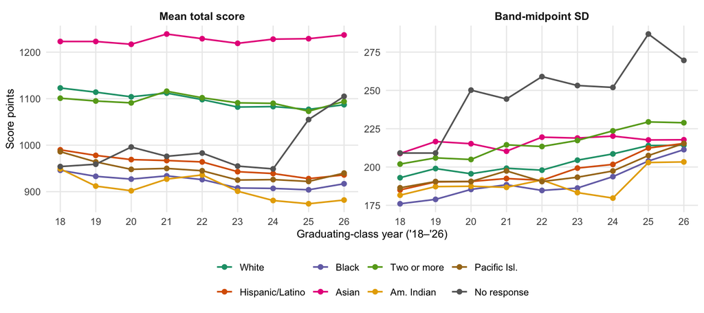

Figure 1: **Mean Total Score and Band-Midpoint SD by Group, 2018–2026.** The left panel shows the published mean total score. The right panel shows the band-midpoint SD, the standard deviation a group’s scores would have if every test-taker in a band scored exactly at that band’s midpoint. It places each band’s published percentage at the nominal midpoints $500, 700, 900, 1100, 1300, 1500$. The exact 10-point-grid midpoints are $495, 695, 895, 1095, 1295, 1500$. The College Board does not publish per-group SDs, so this is a coarse proxy for each group’s SD, not the published cohort SD recovered in Validation. Left panel numbers taken from College Board (2018–2026). Right panel calculated by us from the band percentages in the same reports.

The No Response group behaves differently from the named groups in Figure 1. Its *mean* drifts gently across 2018–2024, jumps by 106 points in 2025, from a published 949 to 1055, and rises another 50 points in 2026, to 1105. No named group’s mean moves by that much in a year. The model allows this because each group has its own free mean parameter $\theta_{r,y}$ in each year, with no smoothness imposed across years. The No Response *standard deviation* rises by about 60 points over the period, in steps in 2020 and 2025, while the named groups’ rise by 9–35 points. The log-linear scale trend the named groups follow cannot reproduce that. The model therefore gives No Response a free scale in each year, outside the named-group hierarchy. The public record cannot say whether this reflects a change in who declines to report a race or in how the same people identify.

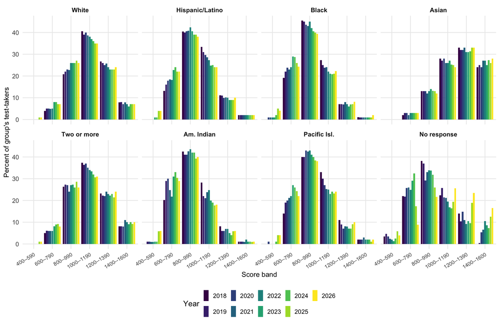

Figure 2: **Score-Band Composition over Time, by Group.** Each panel shows one racial/ethnic group. Score band runs along the horizontal axis, and the nine bars within each band give the percentage of the group’s test-takers in that band, by graduating class from 2018 (darkest) through 2026 (lightest). Numbers taken from College Board (2018–2026). The No Response row was calculated by us by subtraction from the published cohort band counts.

Two more patterns show in Figure 2. Most named-group band shares barely change from year to year. The 1400–1600 share moves by at most four percentage points for every named group. Its range is about 6–8% for White, 24–28% for Asian, 1–2% for Black, and 2% for Hispanic/Latino test-takers, and no wider for the smaller groups. For most bands the nine yearly bars are nearly the same height, which leaves the year-constant skewness and tail-weight little to fit against. The 1000–1190 band, by contrast, declines steadily for White, Black, and Hispanic/Latino test-takers. This mirrors the slow fall in those groups’ published means in Figure 1. From 2018 to 2026 the White mean fell from 1123 to 1087, the Black mean from 946 to 917, and the Hispanic/Latino mean from 990 to 936.

# Methods

The model combines a flexible parametric curve for each group’s score distribution, a likelihood that connects the curve to the rounded band proportions, and a hierarchy that ties the per-group parameters together.

## A Censored Sinh-Arcsinh Shape

For racial/ethnic group $r = 1, \dots, 8$ and graduating-class year $y$, we model an individual total score $S$ as a sinh-arcsinh, or SHASH, random variable (Jones & Pewsey, 2009). The SHASH is a four-parameter generalization of the normal with separate parameters for asymmetry and tail thickness. It is used within the GAMLSS framework for modeling individual-level distributions (Rigby & Stasinopoulos, 2005; Stasinopoulos & Rigby, 2007). If $Z \sim \mathcal{N}(0, 1)$, the standardized SHASH variable is

$$X = \sinh(\frac{\operatorname{asinh}(Z) + \epsilon}{\delta}),
\qquad \delta > 0,
\tag{1}$$

and the score is $S = \mu_{r,y} + \sigma_{r,y} X$, with location $\mu_{r,y}$, scale $\sigma_{r,y}$, skewness $\epsilon_r$, and tail-weight $\delta_r$. Setting $\epsilon = 0,\, \delta = 1$ recovers the standard normal, $\delta < 1$ gives heavier tails and $\delta > 1$ lighter. The skewness and tail-weight are group-level and year-constant, pooled hierarchically. The location is a free per-(group, year) parameter under a weakly informative prior, with the published mean playing no part. The scale varies by year through a per-group log-linear trend plus a small per-cell residual.

The sinh-arcsinh CDF, Equation 2 below, is closed-form. The likelihood evaluates that CDF at five cut points per group and year on every HMC leapfrog step, which rules out families such as Azzalini’s skew-t whose CDF needs numerical integration. The family’s skewness and tail-weight parameters act separately and can be interpreted separately, which the hierarchical pooling relies on. The one alternative with a closed-form CDF and both parameters, the two-piece skew-t of Fernández & Steel (1998), was fit as a check in the Sensitivity section. Its degrees of freedom land near the normal-tail limit, so it offers no tail flexibility the sinh-arcsinh lacks.

Because $\sinh$ and $\operatorname{asinh}$ are monotone, the SHASH CDF is the normal CDF $\Phi$ composed with the inverse transformation,

$$F(s \mid \mu, \sigma, \epsilon, \delta)
= \Phi(\sinh(\delta \operatorname{asinh}(\frac{s - \mu}{\sigma}) - \epsilon)).
\tag{2}$$

Censoring at the reporting range is handled by folding it into the band boundaries. SAT total scores are reported in 10-point steps, so the latent cut between bands “400–590” and “600–790” sits at the midpoint of the gap, 595, and the interior cuts likewise at 795, 995, 1195, 1395. With edges $(-\infty, 595, 795, 995, 1195, 1395, +\infty)$, the bottom band collects mass the smooth distribution would place below 400 and the top band mass above 1600, so the model probability that a member of group $r$ in year $y$ falls in band $b$ is

$$\pi_{r,y,b} = F(e_b \mid \mu_{r,y}, \sigma_{r,y}, \epsilon_r, \delta_r)
- F(e_{b-1} \mid \mu_{r,y}, \sigma_{r,y}, \epsilon_r, \delta_r),
\tag{3}$$

a difference of two closed-form CDF evaluations. The same 10-point convention applies to thresholds later, so a reported score of at least $t$ corresponds to a latent score of at least $t-5$. The band data alone do not identify the shape within the top band.[^2]

Of the four parameters, only the scale is given time structure. The published cohort SD rose from approximately 204 to 235 across 2018–2025, the last year it was published. A model with fixed per-group scales would sit at the all-years average and be too narrow in recent cohorts. For each of the seven *named* groups we let

$$\sigma_{r,y} = \sigma_r \exp(\lambda_r z_y + \eta_{r,y}),
\tag{4}$$

with $\sigma_r$ the mid-period scale, $z_y$ the standardized year, $\lambda_r$ a per-group log-linear growth rate pooled toward a common $\beta_\lambda$, and $\eta_{r,y}$ a residual for each group and year. A tight prior holds the residual near zero, but it is estimated, so the cohort statistics carry its uncertainty. The fitted $\beta_\lambda \approx 0.04$ corresponds to scales about 13% wider in 2026 than in 2018.

The eighth group, “No Response”, receives a free per-year log scale instead of the log-linear trend, for the reasons given in Data.

The per-group-year location is a free parameter $\mu_{r,y}$. The published group mean $\bar S^{\text{pub}}_{r,y}$ is not used in the fit. It and the band percentages come from the same test-takers, so treating the mean as a separate exact fact would double-count. Holding it out also turns the published group means into a check, like the cohort SD and quartiles.

The “Two or More Races” group is fit with the same single SHASH curve, with one skewness and one tail-weight, as each single-race group.[^3]

## A Dirichlet Likelihood on Band Proportions

For each group and year, let $\hat p_{r,y,\bullet} = (\hat p_{r,y,1}, \dots, \hat p_{r,y,6})$ be the six band proportions for that imputation, each in $[0, 1]$ and summing to one by construction. We model these *observed proportions directly*, with no reconstructed counts, as

$$\hat p_{r,y,\bullet} \sim \text{Dirichlet}(\phi_r \pi_{r,y,\bullet}),
\tag{5}$$

where $\pi_{r,y,\bullet}$ are the SHASH band probabilities of Equation 3 and $\phi_r > 0$ is a per-group concentration parameter, pooled hierarchically across groups. The Dirichlet has mean $\pi_{r,y,\bullet}$ and component variances $\pi_{r,y,b}(1 - \pi_{r,y,b})/(\phi_r + 1)$, which do not depend on the group size $N_{r,y}$. A small group is therefore not treated as orders of magnitude noisier than a large one. The per-group concentration, fit from the data, governs the precision of every reported proportion.

Group-size invariance matches how the published percentages were produced. They are *coarsened* in the sense of Heitjan (1989), Heitjan & Rubin (1991), and Heitjan (1994), that is, rounded to the nearest integer percentage point (see also Wang & Heitjan, 2008). That rounding noise is the same size in percentage points for every group. A multinomial likelihood on reconstructed counts would instead treat the largest group’s band proportions as about $\sqrt{N_\text{max}/N_\text{min}} \approx 16$ times more precise than the smallest group’s. In practice it gives only about 13% coverage of nominal 90% predictive intervals. The Dirichlet decouples dispersion from $N$ and lets the per-group concentration absorb the remaining misfit within each group.

Rounding noise is handled outside the Dirichlet by *multiple imputation* (Rubin, 1987), using the rejection sampler described in Data. Each named-group row is drawn uniformly from the part of the simplex that lies inside its rounding box, and No Response is derived by subtraction from the exact published cohort band counts. The full model is fit to each of the $M = 50$ imputed datasets, and the posterior draws are pooled. Printed zeros need no special treatment, because the imputation samples the rounding interval $[0, 0.5)$ directly.

Pooling draws across imputations has a direct Bayesian reading (Rubin, 1987; Gelman et al., 2013, ch. 18). Write $p$ for the true band proportions and $k$ for the printed integers. The pooled draws are then samples from $\int \Pr(\theta \mid p)\, g(p \mid k)\, dp$ with $g$ uniform on the rounding box. That is the exact posterior for $\theta$ under the coarse-data model of Heitjan & Rubin (1991) with a uniform coarsening prior. It differs from the full joint posterior $\Pr(\theta, p \mid k)$ only in that $g$ does not condition on the SHASH likelihood, so proportions the model finds implausible are not down-weighted within the box. Each box is one percentage point wide and the fitted Dirichlet scatter is about two points, so the likelihood is nearly flat across a box and the two posteriors are close. Where they differ, the pooled posterior is wider, so the reported intervals err on the wide side with respect to rounding.

A single concentration per group forces the wide central bands and the narrow tail bands to share one dispersion, where the rounding noise is constant in percentage points and the Dirichlet variance scales with $\pi(1-\pi)$. The resulting over-coverage in the tail bands is documented in the posterior predictive check.

## Hierarchical Structure

All six per-group parameters are pooled hierarchically in the same way, each drawn from a Gaussian centered at a cross-group mean. The smallest groups, Native Hawaiian/Other Pacific Islander and American Indian/Alaska Native, therefore shrink toward the cross-group average instead of tracking their own sampling noise, the usual small-area-estimation logic (Fay & Herriot, 1979; Pfeffermann, 2013; Rao & Molina, 2015) applied to groups rather than areas. The log-scale, the skewness, and the log-scale growth rate are unconstrained, so they are pooled directly,

$$\log\sigma_r \sim \mathcal{N}(\beta_\sigma, \tau_\sigma), \qquad
\epsilon_r \sim \mathcal{N}(\beta_\epsilon, \tau_\epsilon), \qquad
\lambda_r \sim \mathcal{N}(\beta_\lambda, \tau_\lambda).
\tag{6}$$

The tail-weight, the Dirichlet concentration, and the scale-residual SD must be positive, so they are pooled on the log scale,

$$\log\delta_r \sim \mathcal{N}(\beta_\delta, \tau_\delta), \qquad
\log\phi_r \sim \mathcal{N}(\beta_\phi, \tau_\phi), \qquad
\log\tau_{\eta,r} \sim \mathcal{N}(\beta_{\tau_\eta}, \tau_{\tau_\eta}).
\tag{7}$$

The tail-weights are the parameters the band data identify least well, since they govern the shape inside the top band, which six band totals cannot recover. The per-group-year scale residuals themselves are $\eta_{r,y} \sim \mathcal{N}(0, \tau_{\eta,r})$, year-level departures from the log-linear scale trend rather than additional structure. The “No Response” group’s scale is unpooled, as described above. Its skewness $\epsilon_{\text{NR}}$, tail-weight $\delta_{\text{NR}}$, and concentration $\phi_{\text{NR}}$ remain in the hierarchies of Equation 6 and Equation 7.

## Priors and Estimation

The hyperpriors are weakly informative. For the named-group hierarchies on the within-group scale, skewness, and scale-growth rate, each mean has a Gaussian prior and each spread a half-normal prior,

$$\begin{aligned}
\beta_\sigma &\sim \mathcal{N}(\log 230, 0.4), &\quad
\tau_\sigma &\sim \mathcal{N}^{+}(0, 0.35), \\
\beta_\epsilon &\sim \mathcal{N}(0, 0.6), &\quad
\tau_\epsilon &\sim \mathcal{N}^{+}(0, 0.8), \\
\beta_\lambda &\sim \mathcal{N}(0, 0.15), &\quad
\tau_\lambda &\sim \mathcal{N}^{+}(0, 0.06).
\end{aligned}
\tag{8}$$

The hierarchies on the tail-weight, Dirichlet concentration, and scale-residual SD are also weakly informative, and the settings for $\beta_\delta$ and $\tau_\delta$ center each $\delta_r$ near $1$,

$$\begin{aligned}
\beta_\delta &\sim \mathcal{N}(0, 0.3), &\quad
\tau_\delta &\sim \mathcal{N}^{+}(0, 0.2), \\
\beta_\phi &\sim \mathcal{N}(\log 300, 1.5), &\quad
\tau_\phi &\sim \mathcal{N}^{+}(0, 0.5), \\
\beta_{\tau_\eta} &\sim \mathcal{N}(\log 0.03, 0.6), &\quad
\tau_{\tau_\eta} &\sim \mathcal{N}^{+}(0, 0.3).
\end{aligned}
\tag{9}$$

We parameterize the SHASH location $\mu_{r,y}$ by the cell’s *expected score* $\theta_{r,y} = \mathbb{E}[S_{r,y}]$, with prior $\theta_{r,y} \sim \mathcal{N}(1050, 300)$. This is the *centered parameterization* from the skew-normal literature (Azzalini, 1985; Azzalini & Capitanio, 2014), which removes a near-singularity in the likelihood, applied here to the sinh-arcsinh family (Jones & Pewsey, 2009). The raw location is then $\mu_{r,y} = \theta_{r,y} - \sigma_{r,y}\,m(\epsilon_r, \delta_r)$, where $m(\epsilon, \delta) = \mathbb{E}[X]$ is computed by 24-node Gauss–Hermite quadrature once per group per draw. The prior is centered near the overall SAT mean and is wide enough to be essentially flat over plausible group means. The fitted medians run from about 872 to 1250, all within 0.7 prior SDs of the center. It matters only for the smallest groups. The No Response group’s free log scale in each year has prior $\log\sigma_{\text{NR},y} \sim \mathcal{N}(\log 230, 0.4)$, independent across years. The group-level hierarchy uses the non-centered parameterization throughout.

The model is fit by Hamiltonian Monte Carlo in Stan (Betancourt, 2017; Carpenter et al., 2017) via cmdstanr (Gabry et al., 2024) in R (R Core Team, 2024), using the *posterior* (Bürkner et al., 2025), *dplyr* (Wickham et al., 2023), and *ggplot2* (Wickham, 2016) packages. Each of the $M = 50$ imputed datasets is fit with two chains of 1,000 warmup and 1,000 retained iterations at $\text{adapt\_delta} = 0.95$, giving 100,000 pooled draws. Convergence is assessed with the rank-normalized split-$\widehat R$ and effective sample size (Vehtari et al., 2021), and fit with posterior predictive checks (Gelman et al., 1996; Gelman et al., 2013; Meng, 1994; Rubin, 1984) and agreement with held-out summaries, following Gabry et al. (2019). We report 95% credible intervals for the headline quantities and 90% intervals for the per-group parameters. All code and data are available, as described at the end of the paper.

# Results

## Fit and Identification

Table 2 gives the convergence diagnostics across imputations. Raising the HMC adaptation target to $\text{adapt\_delta} = 0.95$ from the cmdstanr default of 0.8 leaves 20 divergent transitions across the 50 imputations, 0.02% of pooled iterations. The worst-case $\widehat R$ and ESS (Vehtari et al., 2021) sit slightly outside the conventional thresholds. The parameters responsible are two cross-group means, the Dirichlet concentration mean $\beta_\phi$ with $\widehat R = 1.022$ and the skewness mean $\beta_\epsilon$ with bulk ESS 204, each in its worst imputation. The per-group $\delta_r$ and $\epsilon_r$, by contrast, have $\widehat R \le 1.008$ and bulk ESS of at least 654 in every imputation. The per-cell $\mu_{r,y}$ and $\sigma_{r,y}$ that carry the headline have $\widehat R \le 1.01$ and bulk ESS of at least 625, with a median of 1,455.

Table 2: **Convergence Diagnostics across Imputations.** Aggregated across the M = 50 imputations. Maximum rank-normalized split-$\widehat R$ and minimum effective sample sizes are taken over per-imputation values, and divergent transitions are summed. Calculated by us from the fitted model, using data from College Board (2018–2026).

| Diagnostic | Value |
| --- | --- |
| Maximum rank-normalized split-$\widehat R$ across imputations | 1.022 |
| Minimum bulk effective sample size across imputations | 204 |
| Minimum tail effective sample size across imputations | 333 |
| Divergent transitions (of 100,000 pooled iterations) | 20 |

The posterior median of the common scale-trend rate is 0.04 (90% CI [0.03, 0.05]), which makes scales about 13% wider in 2026 than in 2018. The per-group rates lie in a narrow band around it. The residuals for each group and year are small, with per-group residual SDs clustering near 0.015, or about 1.5%. The per-group Dirichlet concentrations run around 521, which implies a band-proportion scatter of about 1.8 percentage points. The imputation has already removed rounding noise, so this scatter is year-to-year drift in shape that the year-constant skewness and tail-weight cannot follow.

Table 3 gives the per-group parameters. Scales range from about 190 to 275 across the seven named groups. The tail-weights cluster near 1.12, ranging from 1.108 to 1.127 across the eight groups, just above one. The tails are therefore nearly Gaussian for every group, and the groups differ instead in skewness, which is small but positive for White test-takers, at about 0.05, slightly negative for Asian test-takers, whose scores bunch near the 1600 ceiling with a tail trailing to the left, and about 0.4–0.5 for the lower-mean groups, which have a dense lower bulk and a thin tail of high scorers. The scale-growth rates are all small and similar. The groups therefore differ little in *shape*. The disparities in the high-scoring pool reported below come mostly from differences in means. Two near-normal curves whose means differ by 170 points, the 2026 White-Black gap, have similar centers and very different tails. Appendix Table A1 gives the standard deviation of reported scores that the fitted curves imply for every group and year. The College Board has not published a standard deviation for any racial/ethnic group since 2016 (College Board, 2016).

Table 3: **Per-Group Posterior Parameters for the Seven Named Groups.** Each cell shows the posterior median with the 90% credible interval in brackets. $\sigma_r$ is the mid-period scale, $\epsilon_r$ the year-constant skewness, $\delta_r$ the year-constant tail-weight, and $\lambda_r$ the scale-growth rate, with $\sigma_{r,y} = \sigma_r\exp(\lambda_r z_y + \eta_{r,y})$. The No Response group shares the skewness, tail-weight, and concentration hierarchies, with $\delta_{\text{NR}} \approx 1.12$. Its scale is free in each year rather than set by a $(\sigma_r, \lambda_r)$ pair, so it is not shown. Calculated by us from the fitted model, using data from College Board (2018–2026).

| Group | $\sigma_r$ | $\epsilon_r$ | $\delta_r$ | $\lambda_r$ |
| --- | --- | --- | --- | --- |
| White | 229 [214, 244] | 0.05 [0.01, 0.09] | 1.109 [1.055, 1.158] | 0.039 [0.024, 0.052] |
| Hispanic/Latino | 210 [197, 226] | 0.41 [0.35, 0.48] | 1.126 [1.078, 1.193] | 0.044 [0.030, 0.063] |
| Black | 194 [179, 207] | 0.42 [0.36, 0.48] | 1.108 [1.049, 1.160] | 0.049 [0.034, 0.072] |
| Asian | 274 [258, 298] | -0.08 [-0.17, -0.01] | 1.127 [1.074, 1.218] | 0.033 [0.014, 0.047] |
| Two or more | 252 [237, 272] | 0.19 [0.15, 0.24] | 1.127 [1.080, 1.193] | 0.045 [0.032, 0.061] |
| Am. Indian | 190 [176, 204] | 0.47 [0.41, 0.55] | 1.112 [1.051, 1.166] | 0.038 [0.018, 0.053] |
| Pacific Isl. | 202 [188, 218] | 0.47 [0.39, 0.56] | 1.118 [1.063, 1.179] | 0.041 [0.023, 0.059] |

## Posterior Predictive Check

If the model is calibrated, about 90% of the observed band proportions should lie inside their 90% posterior predictive intervals. We draw replicate proportions $\tilde p_{r,y,\bullet} \sim \text{Dirichlet}(\phi\,\pi_{r,y,\bullet})$ for each of the $8 \times 9 \times 6 = 432$ cells.

In all, 393 of the 432 cells, or 91%, fall inside their interval, against the nominal 90%. The standardized residuals, observed minus predictive median divided by predictive SD, have mean -0.01 and SD 0.75, less than the value of one a calibrated model would produce. The Dirichlet predictive intervals are therefore *wider* than the residuals warrant, especially in the upper bands, where the 1400–1600 band’s residual SD is about 0.4. A single concentration per group cannot match both the wide central bands and the narrow tail bands, and the model errs toward the wide side. A concentration for each band would tighten the tail-band intervals. The over-coverage means the model overstates its uncertainty about the top band and about every quantity derived from it, so the credible intervals reported below are if anything wider than the data justify.

Summed over groups, the fitted band proportions agree with the observed ones to within 1.8 percentage points in every year and band. A bias shared by all groups in a year would show up here even if each cell passed on its own. Figure 3 plots the standardized residual for every group, year, and band. Most scatter around zero with spread well below one, consistent with the over-coverage just described.

Of the 432 cells, 14 fall outside the $\pm 1.645$ lines, 12 for named groups and 2 for No Response. The named-group breaches are all in the 400–590 band, in 2023 through 2026. For the three highest-mean groups, White, Asian, and Two or More Races, the printed share of that band is zero and the model predicts a fraction of a percent. For Hispanic/Latino, Black, and Native Hawaiian/Other Pacific Islander test-takers in 2025 and 2026 the printed share is 4% or 5% and the model predicts 2% to 3%. That band moved more than any other after 2023, and the year-constant skewness cannot follow a change confined to one band. The No Response breaches are all in the lowest band in 2018 and 2019, and they are the two largest residuals in the figure, $4.3$ and $3.6$. In those years the observed mass is well above what a smooth curve fitted to the group’s other bands will accept.

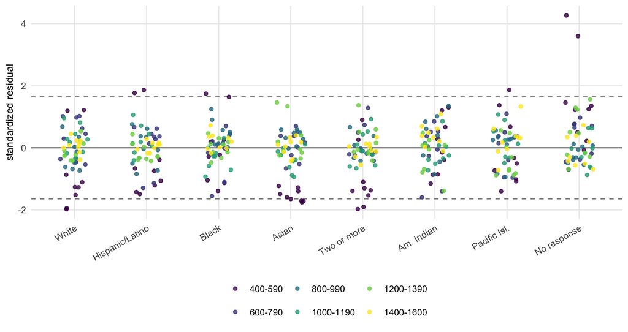

Figure 3: **Standardized Posterior-Predictive Residuals by Group and Band.** Each point is one cell, a group in a given year and band. Dashed lines mark $\pm 1.645$, the Gaussian 90% reference under a calibrated model. The Dirichlet 90% predictive intervals used for the coverage count in the text are asymmetric, so the number of points outside the dashed lines need not equal the number of cells outside those intervals. Color shows the score band. Observed proportions taken from College Board (2018–2026). Predictive intervals calculated by us from the fitted model.

## Validation

This section tests the method on the whole cohort, the one population for which the College Board publishes the quantities the model predicts. Each annual report through 2025 prints five cohort numbers besides the band breakdown the model is fit to. They are the mean total score, the standard deviation, and the 25th, 50th, and 75th percentile scores. None enters the model, and they differ in how strong a check they provide. The cohort mean is a weighted average of the band proportions the model fits, and a model that matches the bands recovers it almost mechanically, so it is only a consistency check. The cohort SD is less tightly constrained, since the per-group scale trend and residuals can fit it without being pinned by the bands. The quartiles test the shape of the body of the distribution out of sample. The bands fix the CDF at the five interior cut points, and where the published $p_{25}$, $p_{50}$, and $p_{75}$ fall between them depends on the parametric form. Across 2018–2026 that gives 44 cohort numbers, since the 2026 report omits the SD, and the 27 quartiles are the out-of-sample test.

Figure 4 compares the mean and SD in score points. Reported quartile scores lie on the 10-point grid, so for them we compare ranks instead. Figure 5 shows the model’s posterior rank of each published quartile, which should equal 0.25, 0.50, or 0.75.

Locating each curve from the bands alone, the model recovers the published cohort mean to within a few points every year, and the group means as well. Across the 63 named-group cells the median gap between recovered and published means is about 3 points, and the published value lies inside the model’s 95% interval in 100% of cells. Only the No Response group falls clearly outside its interval, by up to 33 points. Its mean is exactly derivable by subtraction, but its band-proportion fit is looser because of the volatility shown in Figure 1. The model’s cohort SD rises from about 208 in 2018 to about 240 in 2025, tracking the published rise from about 204 to 235. The small residual for each year lets it follow year-to-year fluctuations, but not entirely. In 2018 the published SD sits at the edge of the posterior interval, just outside it. The quartile ranks are within about a percentage point of nominal in most years. The largest deviations are about $+2$ points for $p_{25}$ in 2018 and 2026 and about $+1.5$ points for $p_{75}$ in 2025 and 2026, reflecting the recent right-skew residual. Overall, the published value lies inside the model’s 95% interval in 82% of the 44 cells. That is 77% of the 35 SD and quartile cells and 9 of the 9 mean cells. The misses are small and mostly at the interval’s edge.

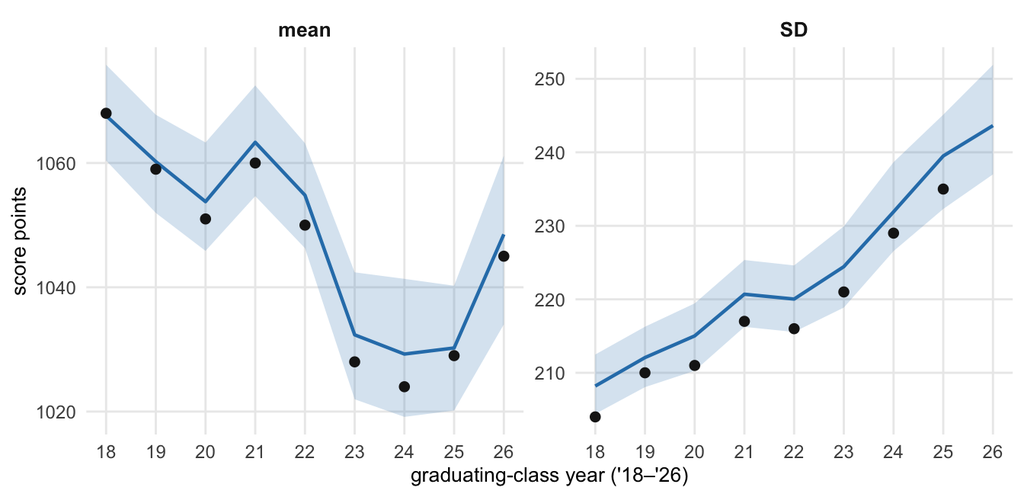

Figure 4: **Held-Out Cross-Check of the Cohort Mean and Standard Deviation.** By graduating-class year. Neither summary was used in fitting. The model was fit only to the six banded percentages for each group and year, and the implied cohort mean and SD are computed as population-weighted moments of the fitted group distributions. The blue line is the posterior median of the model’s implied cohort value, and the shaded band is its 95% credible interval. Black points are the College Board’s published values. The 2026 report gives no SD, so the SD panel has no 2026 point. Y-axes differ between panels. Black points taken from College Board (2018–2026). Model values calculated by us from the fitted model.

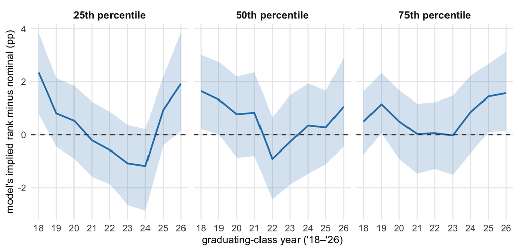

Figure 5: **Held-Out Cross-Check of the Published Cohort Quartile Scores.** By graduating-class year. For each year the College Board reports the scores at the cohort’s 25th, 50th, and 75th percentiles. We plug each of those scores into the model’s posterior cumulative distribution to get the percentile the model assigns to it, its implied rank. A perfectly calibrated model places the published 25th-percentile score at percentile 25, the median at 50, and the 75th-percentile score at 75. The vertical axis shows the implied rank minus the nominal value, so the dashed zero line is perfect agreement. The blue line is the posterior median and the shaded band the 95% credible interval. None of the published quartiles was used in fitting. Published quartile scores taken from College Board (2018–2026). Implied ranks calculated by us from the fitted model.

A second, finer check is independent of the band summaries. The College Board’s *SAT User Percentile* table gives, in 10-point steps, the cumulative share of test-takers at or below each total score in the three most recently graduated cohorts pooled. It is built from individual scores, and we hold it out of the fit.

Below 1400 this comparison tests little. The six band proportions pin the cohort survival curve at five band boundaries, and any smooth curve through them tracks those anchors to within rounding. Above 1400 the band data give a single anchor, at the bottom of the top band, and the SHASH form fills in the rest. The table is the only check on the shape inside that band.

The College Board has published the SAT User Percentile table for five pooled three-year windows, from 2018–2020 through 2023–2025, with no table for 2020–2022 (College Board, 2020b, 2021b, 2023b, 2024c, 2025b). The table is replaced each year, so we cite an archived copy of each window. For the most recent window we compute the model’s implied cohort survival curve by population-weighting the per-group SHASH curves over the three years, and Figure 6 compares it with the published table. The table reports an integer percentile at each 10-point score, so the true $P(\text{score}\ge t)$ lies in a band one percentage point wide, or half a point wide at the top scores reported as “99+”. Through the body of the distribution the model’s posterior median runs within about one percentage point of the band, mostly a little below it. The exact cohort anchors at the band boundaries sit below the table’s band by a similar amount, so that offset reflects a small difference between the two College Board sources rather than the model. From 1400 to 1500 the median lies inside the band or within 0.2 points of it. For 2023–2025 the model puts 3.1% (90% interval 2.8% to 3.4%) above 1500, and the table’s band runs from 2.5% to 3.5%. From 1550 upward the model drifts above the band by about 0.3 to 1.2 percentage points, until integer rounding at the top of the table makes further comparison impossible. The four earlier windows show the same pattern and are not reproduced here.

From 1550 upward the model places somewhat *more* cohort mass than the table does. The cohort-level counts at 1550 and 1580 reported below are therefore more likely too high than too low.

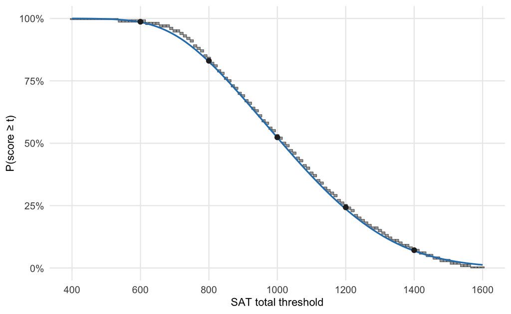

Figure 6: **External Held-Out Validation against the SAT User Percentile Reference, 2023–2025 Pooled Cohort.** Grey rectangles show the range of $P(\text{score} \ge t)$ consistent with the integer SAT User Percentile at $t-10$. Each is one percentage point tall, or half a point at the top scores reported as ‘99+’. The solid blue line is the model’s posterior median cohort $P(\text{score} \ge t)$, population-weighted across 2023–2025. Black points are the exact cohort survival at the band boundaries 600, 800, 1000, 1200, and 1400. Plots for the four earlier windows look similar and are omitted. Grey bands taken from the College Board’s SAT User Percentile table for the 2023–2025 window. Black points calculated by us from the band counts in College Board (2023–2025). Blue line calculated by us from the fitted model.

## Sensitivity to the Parametric Family and Priors

The shape within the top band, which the headline quantities depend on, comes from the parametric form. We therefore ask how much those quantities move under a different form or under looser priors on the shape parameters. We refit three variants with the canonical sampler settings, all to the first of the 50 imputed datasets, so that the comparison isolates the modeling choice from rounding noise. The first is the two-piece skew-t of Fernández & Steel (1998), the one alternative family with a closed-form CDF and separate skewness and tail parameters. Its per-group skewness $\gamma_r$ and degrees of freedom $\nu_r$ are pooled hierarchically in place of $\epsilon_r$ and $\delta_r$. The second is the canonical model with the between-group tail-weight hyperprior widened five-fold, $\tau_\delta \sim \mathcal{N}^{+}(0, 1.0)$ in place of $\mathcal{N}^{+}(0, 0.2)$. The third is the canonical model with year-varying skewness, $\epsilon_{r,y} = \epsilon_r + \tau_{\epsilon\text{-year}}\,\eta^{\epsilon}_{r,y}$, which relaxes the only restriction across years on the shape parameters.

The canonical row of Table 4 uses a single imputation, so its median of 1.19% differs from the pooled headline of 1.3%. Across the 50 imputations the canonical medians run from 1.01% to 1.58%. Integer rounding of the published percentages therefore moves the headline more than the choice of tail family does, and the pooled interval already includes that rounding uncertainty. The single-imputation fits in Table 4 omit rounding uncertainty, so their intervals are narrower than those reported elsewhere. Every variant is also a smooth unimodal curve, so a family with a separate bump near the ceiling could differ from all of them above 1550 with no public data to tell them apart. Within the class of smooth curves, the structural uncertainty in the headline is small relative to the pooled interval. Appendix Table A4 gives every group’s share of the 1500+ and 1580+ pools under each of the four fits.

Table 4: **Headline Quantities under Alternative Model Specifications, 2026.** Each cell is the posterior median with the 95% credible interval in brackets, from a fit to the first of the 50 imputed datasets. The canonical row is the canonical model fit to that same imputation, so the four rows are directly comparable. The intervals omit rounding uncertainty and are narrower than the pooled intervals elsewhere in the paper. Every per-group quantity above 1400 is an extrapolation, and 1550 and 1580 also lie beyond the cohort-level check at 1500. Calculated by us from the fitted models, using data from College Board (2018–2026).

| Model | Black share of 1500+ (%) | Black share of 1550+ (%) | Black share of 1580+ (%) | Asian/Black ratio, 1500+ |
| --- | --- | --- | --- | --- |
| Canonical sinh-arcsinh | 1.2 [0.7, 1.9] | 0.9 [0.5, 1.5] | 0.7 [0.4, 1.3] | 30 [19, 50] |
| Two-piece skew-t | 1.3 [0.9, 2.0] | 1.0 [0.6, 1.7] | 0.9 [0.5, 1.5] | 27 [18, 41] |
| Wide tail-weight prior | 1.2 [0.7, 1.9] | 0.9 [0.5, 1.5] | 0.7 [0.4, 1.3] | 30 [19, 51] |
| Year-varying skewness | 1.2 [0.7, 2.0] | 0.9 [0.5, 1.6] | 0.7 [0.4, 1.4] | 30 [19, 50] |

# Composition of the High-Scoring Pool

Table 5 gives the estimated share and number of 2026 test-takers scoring at or above 1500, 1550, and 1580, for the whole cohort and for the Asian, White, and Black groups. Appendix Table A3 gives the same quantities, and each group’s share of the pool, for all eight groups. Figure 7 shows the Asian-to-Black ratio and the Black share of the pool above each threshold, and also at the 1400 band boundary. At 1400 the values follow directly from the published numbers, subject to their integer rounding of $\pm 0.5$ percentage points, which matters when the printed share is itself near 1%. The ratio of Asian to Black test-takers above 1400 is about 13 to one, and Black students are about 2.8% of that pool. The three higher thresholds fall inside the top band, where the model interpolates. The Asian-to-Black ratio rises from about 29 to one at 1500 (95% CI 17 to 51) to about 38 at 1550 (20 to 74) and 45 at 1580 (23 to 94). The intervals widen faster than the medians because the rounding uncertainty in the inputs grows in relative terms as the thresholds rise.

The No Response group is 11% of 2026 test-takers. Because its 2026 distribution is wide, the model puts it at about 34% of the pool above 1500. Every share in Table 5 and Figure 7 uses all eight groups as the denominator. If test-takers who declined to report a race differ in composition from those who did, the named-group shares are diluted unevenly, and the data cannot say by how much. Using only test-takers who reported a race as the denominator gives a 2026 Black share of the 1500+ pool of 1.9% (95% CI 1.1% to 3.2%). The headline lies between these two figures, and the Asian-to-Black ratio is the same under either denominator.

Table 5: **Share and Number of 2026 Test-Takers Scoring at or above Three Thresholds.** For the whole cohort and for three groups, the percentage of the group’s test-takers at or above each threshold and the implied count. Each entry is a posterior median with the 95% credible interval in brackets. All three thresholds lie inside the top band, so every per-group value is an extrapolation beyond the last point checked by group, 1400. The cohort total is externally checked through 1500 but not at 1550 or 1580. Calculated by us from the fitted model, using the test-taker counts and band percentages in College Board (2026, pp. 9 and 11).

| Group | Share of group at or above (%) | Number at or above |
| --- | --- | --- |
| **At or above 1500** |  |  |
| Whole cohort | 4.8 [3.9, 5.8] | 94,005 [76,901, 114,132] |
| Asian | 16.1 [14.0, 18.5] | 34,779 [30,284, 39,982] |
| White | 2.7 [2.0, 3.4] | 18,523 [13,995, 23,901] |
| Black | 0.5 [0.3, 0.8] | 1,204 [695, 1,983] |
| **At or above 1550** |  |  |
| Whole cohort | 3.4 [2.6, 4.4] | 66,163 [50,814, 85,310] |
| Asian | 11.2 [9.3, 13.4] | 24,233 [20,074, 29,048] |
| White | 1.5 [1.0, 2.0] | 10,136 [7,169, 13,850] |
| Black | 0.3 [0.1, 0.5] | 636 [334, 1,136] |
| **At or above 1580** |  |  |
| Whole cohort | 2.7 [2.0, 3.7] | 53,368 [39,048, 71,911] |
| Asian | 8.8 [7.0, 10.9] | 19,037 [15,144, 23,549] |
| White | 1.0 [0.7, 1.4] | 6,847 [4,624, 9,732] |
| Black | 0.2 [0.1, 0.3] | 425 [210, 800] |

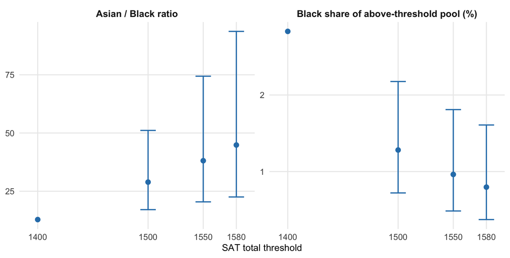

Figure 7: **Principal Tail Quantities for the 2026 Graduating Class.** The left panel shows the Asian-to-Black ratio of test-takers at or above each threshold. The right panel shows the Black share of all test-takers above each threshold. At 1400 the values follow directly from the College Board’s published numbers and have no credible interval. Their only uncertainty is the $\pm 0.5$ percentage-point rounding of each group’s share of the 1400–1600 band, discussed in the text. The three higher thresholds fall inside the top band, where the model interpolates. Points are posterior medians and bars are 95% credible intervals. All values above 1400 are extrapolations beyond the last point checked by group, and the 1550 and 1580 values also lie beyond the cohort-level check at 1500. The 1400 values are taken from College Board (2026, pp. 9 and 11). The rest are calculated by us from the fitted model.

# Discussion

The 2026 graduating class contained 1,954,833 SAT test-takers, with a published mean total score of 1045, taken from the College Board’s annual report, which for the first time gives no standard deviation. The published 2026 means were 1237 for Asian, 1087 for White, and 917 for Black test-takers. From the fitted model, about 4.8% of the cohort, roughly 94,005 test-takers, scored 1500 or higher. The corresponding figures are 16.1% and about 34,779 for the Asian group and 2.7% and about 18,523 for the White group. For the Black group they are 0.5% and about 1,204. As a share of the 1500+ pool, Black test-takers are between 0.7% and 2.2% (posterior median 1.3%), and the ratio of Asian to Black test-takers in that pool is about 29 (17 to 51) to one. At 1550 the model puts about 3.4% of the cohort, or 66,163 test-takers, at or above the threshold. The Asian, White, and Black counts are about 24,233, 10,136, and 636. Table 5 gives the 1580 figures and every interval. All of these counts are of test-takers.

We do not convert scores, gaps, or thresholds to IQ equivalents. No concordance between the current SAT, in use since 2016, and any IQ test has been published. A conversion based on the test-taker mean and SD would also look like a population IQ even though test-takers are a self-selected half of the age cohort. That is the step from test-takers to the age cohort that we do not take. A standardized gap, Cohen’s $d$ against the cohort SD, does not need that assumption. Appendix Table A2 gives it for every pair of groups in 2026.

The sinh-arcsinh family (Jones & Pewsey, 2009) is well established for modeling individual-level distributions, principally within GAMLSS (Rigby & Stasinopoulos, 2005; Stasinopoulos & Rigby, 2007). To our knowledge it has not been fit to banded score data with a Dirichlet likelihood, and no one has fit a full parametric score distribution for each group and year from the College Board’s public banded summaries. Published work on group differences in SAT performance has either relied on individual scores (e.g. Sackett et al., 2009; Kobrin & Patterson, 2011; Kuncel & Hezlett, 2010) or stayed at the level of published moments (e.g. Roth et al., 2001; Hauser, 2002). The literature on inferring gaps from coarse public data (Reardon, 2011; Reardon et al., 2019) has not paired a parametric within-group distribution with a likelihood on the proportions themselves.

The SHASH form interpolates the shape within the 1400–1600 band that the band data cannot identify. A credible interval from a single model does not include uncertainty about the model itself. The Sensitivity section shows that an alternative tail family, a five-fold wider tail-weight prior, and year-varying skewness move the headline medians by less than the width of the canonical interval. Every variant is a smooth unimodal curve, however, so the check cannot rule out shapes outside that class. Each published category also pools groups the data cannot separate, so the Asian and Two or More Races estimates describe the published category, not any population within it. The Two or More Races group is also, by construction, a mixture fit with a single smooth curve. The No Response category also appears in every denominator, so the named-group shares depend on its unknown composition. The Composition section gives the range.

All of this modeling is necessary only because of how the data are published. The College Board holds the individual scores from which every quantity in this paper could be read off directly. It publishes, per group, six integer-rounded percentages, and its 2026 report no longer prints even the cohort’s standard deviation (College Board, 2026). Counts by group in 50-point bins would make this model unnecessary, as would a per-group version of the SAT User Percentile table the College Board already publishes for the cohort. Either would answer both of this paper’s questions exactly. The same model can be fit to any testing report that publishes per-group banded distributions, such as the ACT or PISA, with whatever other summaries the report publishes held out as checks, as the cohort SD and quartiles are here.

# Data and Code Availability

The College Board reports used here are public. They are the Total Group annual reports for 2018 through 2026 and the SAT User Percentile tables for the five windows cited in Validation. Copies of those files, the extraction scripts, the cleaned data, the Stan model, and the code that produced every table and figure in this paper are in a public repository at https://github.com/davidkane9/sat-total-scores.

# References

Azzalini, A. (1985). A class of distributions which includes the normal ones. *Scandinavian Journal of Statistics*, *12*(2), 171–178.

Azzalini, A., & Capitanio, A. (2014). *The skew-normal and related families*. Cambridge University Press. https://doi.org/10.1017/CBO9781139248891

Betancourt, M. (2017). A conceptual introduction to Hamiltonian Monte Carlo. *arXiv Preprint arXiv:1701.02434*. https://doi.org/10.48550/arXiv.1701.02434

Bürkner, P.-C., Gabry, J., Kay, M., & Vehtari, A. (2025). *posterior: Tools for working with posterior distributions*.

Carpenter, B., Gelman, A., Hoffman, M. D., Lee, D., Goodrich, B., Betancourt, M., Brubaker, M. A., Guo, J., Li, P., & Riddell, A. (2017). Stan: A probabilistic programming language. *Journal of Statistical Software*, *76*(1), 1–32. https://doi.org/10.18637/jss.v076.i01

College Board. (2016). *2016 college-bound seniors: Total group profile report*. College Board, New York.

College Board. (2018). *SAT suite of assessments annual report: Total group*. College Board, New York.

College Board. (2019). *SAT suite of assessments annual report: Total group*. College Board, New York.

College Board. (2020a). *SAT suite of assessments annual report: Total group*. College Board, New York.

College Board. (2020b). *Understanding SAT scores: SAT user percentiles, graduating classes of 2018–2020*. College Board, New York.

College Board. (2021a). *SAT suite of assessments annual report: Total group*. College Board, New York.

College Board. (2021b). *Understanding SAT scores: SAT user percentiles, graduating classes of 2019–2021*. College Board, New York.

College Board. (2022a). *SAT suite of assessments annual report: Total group*. College Board, New York.

College Board. (2022b). *Transitioning to a digital SAT: Ensuring tests and scores are valid, reliable, and fair*. College Board, New York.

College Board. (2023a). *SAT suite of assessments annual report: Total group*. College Board, New York.

College Board. (2023b). *Understanding SAT scores: SAT user percentiles, graduating classes of 2021–2023*. College Board, New York.

College Board. (2024a). *SAT suite of assessments annual report: Total group*. College Board, New York.

College Board. (2024b). *SAT suite of assessments technical manual*. College Board, New York.

College Board. (2024c). *Understanding SAT scores: SAT user percentiles, graduating classes of 2022–2024*. College Board, New York.

College Board. (2025a). *SAT suite of assessments annual report: Total group*. College Board, New York.

College Board. (2025b). *Understanding SAT scores: SAT user percentiles, graduating classes of 2023–2025*. College Board, New York.

College Board. (2026). *SAT suite of assessments annual report: Total group*. College Board, New York.

Fay, R. E., & Herriot, R. A. (1979). Estimates of income for small places: An application of James–Stein procedures to census data. *Journal of the American Statistical Association*, *74*(366), 269–277. https://doi.org/10.1080/01621459.1979.10482505

Fernández, C., & Steel, M. F. J. (1998). On Bayesian modeling of fat tails and skewness. *Journal of the American Statistical Association*, *93*(441), 359–371. https://doi.org/10.1080/01621459.1998.10474117

Frey, M. C., & Detterman, D. K. (2004). Scholastic assessment or $g$? The relationship between the Scholastic Assessment Test and general cognitive ability. *Psychological Science*, *15*(6), 373–378. https://doi.org/10.1111/j.0956-7976.2004.00687.x

Gabry, J., Češnovar, R., Johnson, A., & Bronder, S. (2024). *cmdstanr: R interface to CmdStan*.

Gabry, J., Simpson, D., Vehtari, A., Betancourt, M., & Gelman, A. (2019). Visualization in Bayesian workflow. *Journal of the Royal Statistical Society, Series A*, *182*(2), 389–402. https://doi.org/10.1111/rssa.12378

Gelman, A., Carlin, J. B., Stern, H. S., Dunson, D. B., Vehtari, A., & Rubin, D. B. (2013). *Bayesian data analysis* (3rd ed.). Chapman & Hall/CRC. https://doi.org/10.1201/b16018

Gelman, A., Meng, X.-L., & Stern, H. (1996). Posterior predictive assessment of model fitness via realized discrepancies. *Statistica Sinica*, *6*(4), 733–760.

Hauser, R. M. (2002). *Meritocracy, cognitive ability, and the sources of occupational success* (Center for Demography & Ecology Working Paper 98-07 (rev.)). Center for Demography & Ecology, University of Wisconsin–Madison.

Heitjan, D. F. (1989). Inference from grouped continuous data: A review. *Statistical Science*, *4*(2), 164–179. https://doi.org/10.1214/ss/1177012601

Heitjan, D. F. (1994). Ignorability in general incomplete-data models. *Biometrika*, *81*(4), 701–708. https://doi.org/10.1093/biomet/81.4.701

Heitjan, D. F., & Rubin, D. B. (1991). Ignorability and coarse data. *The Annals of Statistics*, *19*(4), 2244–2253. https://doi.org/10.1214/aos/1176348396

Jones, M. C., & Pewsey, A. (2009). Sinh-arcsinh distributions. *Biometrika*, *96*(4), 761–780. https://doi.org/10.1093/biomet/asp053

Kane, D. (2026). After SFFA v. Harvard: Predictions that didn’t come true. *Econ Journal Watch*, *23*(2), 485–508.

Kobrin, J. L., & Patterson, B. F. (2011). Contextual factors associated with the validity of SAT scores and high school GPA for predicting first-year college grades. *Educational Assessment*, *16*(4), 207–226. https://doi.org/10.1080/10627197.2011.635956

Kuncel, N. R., & Hezlett, S. A. (2010). Fact and fiction in cognitive ability testing for admissions and hiring decisions. *Current Directions in Psychological Science*, *19*(6), 339–345. https://doi.org/10.1177/0963721410389459

Lemann, N. (1999). *The big test: The secret history of the American meritocracy*. Farrar, Straus & Giroux.

Meng, X.-L. (1994). Posterior predictive p-values. *Annals of Statistics*, *22*(3), 1142–1160. https://doi.org/10.1214/aos/1176325622

Pfeffermann, D. (2013). New important developments in small area estimation. *Statistical Science*, *28*(1), 40–68. https://doi.org/10.1214/12-STS395

R Core Team. (2024). *R: A language and environment for statistical computing*. R Foundation for Statistical Computing.

Rao, J. N. K., & Molina, I. (2015). *Small area estimation* (2nd ed.). Wiley. https://doi.org/10.1002/9781118735855

Reardon, S. F. (2011). The widening academic-achievement gap between the rich and the poor: New evidence and possible explanations. In G. J. Duncan & R. J. Murnane (Eds.), *Whither opportunity? Rising inequality, schools, and children’s life chances* (pp. 91–116). Russell Sage Foundation.

Reardon, S. F., Kalogrides, D., & Shores, K. (2019). The geography of racial/ethnic test score gaps. *American Journal of Sociology*, *124*(4), 1164–1221. https://doi.org/10.1086/700678

Rigby, R. A., & Stasinopoulos, D. M. (2005). Generalized additive models for location, scale and shape. *Journal of the Royal Statistical Society, Series C*, *54*(3), 507–554. https://doi.org/10.1111/j.1467-9876.2005.00510.x

Roth, P. L., Bevier, C. A., Bobko, P., Switzer, F. S., & Tyler, P. (2001). Ethnic group differences in cognitive ability in employment and educational settings: A meta-analysis. *Personnel Psychology*, *54*(2), 297–330. https://doi.org/10.1111/j.1744-6570.2001.tb00094.x

Rubin, D. B. (1984). Bayesianly justifiable and relevant frequency calculations for the applied statistician. *Annals of Statistics*, *12*(4), 1151–1172. https://doi.org/10.1214/aos/1176346785

Rubin, D. B. (1987). *Multiple imputation for nonresponse in surveys*. Wiley. https://doi.org/10.1002/9780470316696

Sackett, P. R., Kuncel, N. R., Arneson, J. J., Cooper, S. R., & Waters, S. D. (2009). Does socioeconomic status explain the relationship between admissions tests and post-secondary academic performance? *Psychological Bulletin*, *135*(1), 1–22. https://doi.org/10.1037/a0013978

Stasinopoulos, D. M., & Rigby, R. A. (2007). Generalized additive models for location scale and shape (GAMLSS) in R. *Journal of Statistical Software*, *23*(7), 1–46. https://doi.org/10.18637/jss.v023.i07

Students for Fair Admissions, Inc. v. President and Fellows of Harvard College, 600 U.S. 181 (2023).

Vehtari, A., Gelman, A., Simpson, D., Carpenter, B., & Bürkner, P.-C. (2021). Rank-normalization, folding, and localization: An improved $\widehat{R}$ for assessing convergence of MCMC. *Bayesian Analysis*, *16*(2), 667–718. https://doi.org/10.1214/20-BA1221

Wang, H., & Heitjan, D. F. (2008). Modeling heaping in self-reported cigarette counts. *Statistics in Medicine*, *27*(19), 3789–3804. https://doi.org/10.1002/sim.3281

Westrick, P. A., Marini, J. P., Young, L., Ng, H., Shmueli, D., & Shaw, E. J. (2019). *Validity of the SAT for predicting first-year grades and retention to the second year* [College Board Research Report]. College Board.

Wickham, H. (2016). *ggplot2: Elegant graphics for data analysis* (2nd ed.). Springer-Verlag. https://ggplot2.tidyverse.org

Wickham, H., François, R., Henry, L., Müller, K., & Vaughan, D. (2023). *dplyr: A grammar of data manipulation*.

# Appendix

The main text reports several quantities for the cohort or for the Asian, White, and Black groups only. The four tables here give the same quantities for all eight groups. Every number comes from the same posterior draws, or the same published figures, as the main text.

## Estimated Standard Deviations by Group and Year

The College Board has not printed a standard deviation for any racial/ethnic group since 2016. Appendix Table A1 gives the standard deviation of reported scores on the 400–1600 grid that the fitted curve implies for each group and year, with the model’s cohort SD and the published cohort SD for comparison. The cohort rows are the quantities plotted in Figure 4.

**Appendix Table A1. Estimated Standard Deviation of Total Scores by Group and Year, 2018–2020.** Each cell is the posterior median with the 95% credible interval in brackets, in score points, for the distribution of reported scores on the 400–1600 grid implied by the fitted curve. The model cohort row is the population-weighted mixture of the eight group curves. The College Board publishes no per-group SD. Published cohort SDs taken from College Board (2018–2020). All other values calculated by us from the fitted model.

| Group | 2018 | 2019 | 2020 |
| --- | --- | --- | --- |
| White | 187 [180, 194] | 191 [185, 197] | 192 [186, 198] |
| Hispanic/Latino | 179 [171, 187] | 182 [175, 189] | 183 [176, 190] |
| Black | 169 [161, 176] | 171 [163, 178] | 175 [168, 182] |
| Asian | 214 [207, 222] | 219 [211, 227] | 220 [213, 227] |
| Two or more | 201 [194, 208] | 204 [198, 211] | 206 [199, 212] |
| Am. Indian | 172 [164, 182] | 175 [167, 183] | 177 [169, 184] |
| Pacific Isl. | 180 [170, 189] | 182 [174, 192] | 184 [176, 193] |
| No response | 188 [153, 235] | 194 [152, 250] | 244 [199, 290] |
| Cohort, model | 208 [204, 212] | 212 [208, 217] | 215 [211, 220] |
| Cohort, published | 204 | 210 | 211 |

**Appendix Table A1, continued. Estimated Standard Deviation of Total Scores by Group and Year, 2021–2023.** Layout and sources as in the first part of the table. Published cohort SDs taken from College Board (2021–2023). All other values calculated by us from the fitted model.

| Group | 2021 | 2022 | 2023 |
| --- | --- | --- | --- |
| White | 194 [189, 200] | 196 [190, 202] | 200 [194, 206] |
| Hispanic/Latino | 188 [181, 195] | 190 [182, 196] | 193 [185, 200] |
| Black | 179 [172, 186] | 180 [173, 187] | 183 [176, 190] |
| Asian | 219 [213, 225] | 224 [218, 232] | 226 [220, 233] |
| Two or more | 211 [205, 218] | 213 [206, 219] | 217 [210, 222] |
| Am. Indian | 179 [171, 186] | 181 [174, 189] | 182 [173, 190] |
| Pacific Isl. | 187 [179, 196] | 189 [180, 198] | 191 [182, 200] |
| No response | 230 [187, 275] | 238 [193, 280] | 241 [196, 285] |
| Cohort, model | 220 [216, 225] | 220 [216, 225] | 225 [220, 230] |
| Cohort, published | 217 | 216 | 221 |

**Appendix Table A1, continued. Estimated Standard Deviation of Total Scores by Group and Year, 2024–2026.** Layout and sources as in the first part of the table. The 2026 report gives no cohort SD. Published cohort SDs taken from College Board (2024–2025). All other values calculated by us from the fitted model.

| Group | 2024 | 2025 | 2026 |
| --- | --- | --- | --- |
| White | 203 [197, 209] | 207 [200, 214] | 209 [202, 216] |
| Hispanic/Latino | 196 [188, 204] | 202 [194, 210] | 205 [197, 214] |
| Black | 187 [180, 195] | 193 [185, 202] | 198 [189, 209] |
| Asian | 228 [221, 235] | 229 [221, 236] | 229 [222, 237] |
| Two or more | 220 [214, 226] | 226 [219, 234] | 227 [220, 235] |
| Am. Indian | 183 [173, 192] | 190 [182, 199] | 193 [184, 203] |
| Pacific Isl. | 195 [186, 204] | 200 [190, 209] | 203 [192, 213] |
| No response | 247 [201, 295] | 296 [251, 345] | 291 [247, 341] |
| Cohort, model | 232 [226, 238] | 239 [233, 246] | 244 [237, 252] |
| Cohort, published | 229 | 235 |  |

## Standardized Differences Between Group Means

Appendix Table A2 gives Cohen’s $d$ for every pair of groups in 2026, computed from the published group means and the model’s estimate of the 2026 cohort SD, 244, from Appendix Table A1. The College Board published a cohort SD through 2025, and the model’s estimate for each of those years is within a few points of it. We use the cohort SD as the denominator, rather than a pooled within-group SD, so that every pair is on one scale. The Discussion explains why we report standardized gaps rather than IQ equivalents.

**Appendix Table A2. Cohen’s $d$ Between Published Group Means, 2026.** One row per pair of groups, the higher-mean group first, with groups ordered by mean. The difference in published means, in score points, is divided by the model’s estimated 2026 cohort SD. Means taken from College Board (2026, p. 9). SD and $d$ calculated by us from the fitted model.

| Higher-mean group | Lower-mean group | Difference in means | Cohen’s $d$ |
| --- | --- | --- | --- |
| Asian | No response | 132 | 0.54 |
| Asian | Two or more | 143 | 0.59 |
| Asian | White | 150 | 0.61 |
| Asian | Pacific Isl. | 297 | 1.22 |
| Asian | Hispanic/Latino | 301 | 1.23 |
| Asian | Black | 320 | 1.31 |
| Asian | Am. Indian | 355 | 1.45 |
| No response | Two or more | 11 | 0.05 |
| No response | White | 18 | 0.07 |
| No response | Pacific Isl. | 165 | 0.68 |
| No response | Hispanic/Latino | 169 | 0.69 |
| No response | Black | 188 | 0.77 |
| No response | Am. Indian | 223 | 0.91 |
| Two or more | White | 7 | 0.03 |
| Two or more | Pacific Isl. | 154 | 0.63 |
| Two or more | Hispanic/Latino | 158 | 0.65 |
| Two or more | Black | 177 | 0.73 |
| Two or more | Am. Indian | 212 | 0.87 |
| White | Pacific Isl. | 147 | 0.60 |
| White | Hispanic/Latino | 151 | 0.62 |
| White | Black | 170 | 0.70 |
| White | Am. Indian | 205 | 0.84 |
| Pacific Isl. | Hispanic/Latino | 4 | 0.02 |
| Pacific Isl. | Black | 23 | 0.09 |
| Pacific Isl. | Am. Indian | 58 | 0.24 |
| Hispanic/Latino | Black | 19 | 0.08 |
| Hispanic/Latino | Am. Indian | 54 | 0.22 |
| Black | Am. Indian | 35 | 0.14 |

## Shares and Counts above Each Threshold, All Groups

Appendix Table A3 extends Table 5 to all eight groups and adds each group’s share of the pool at or above each threshold. At 1400 the values follow from the published band percentages, subject to their integer rounding, and carry no model interval. At the three higher thresholds they come from the pooled posterior.

**Appendix Table A3. Share of Each Group Scoring at or above Four Thresholds, Number of Test-Takers, and Share of the Pool, 2026.** Cells at 1500 and above are the posterior median with the 95% credible interval in brackets. Cells at 1400 are computed directly from the published band percentages and have no interval. Every value above 1400 is an extrapolation. The pool share is the group’s count divided by the total count at or above the threshold, with all eight groups in the denominator. Band percentages and group sizes taken from College Board (2026, pp. 9 and 11). Model values calculated by us from the fitted model.

| Group | Share of group (%) | Number | Share of pool (%) |
| --- | --- | --- | --- |
| **At or above 1400** |  |  |  |
| Cohort | 8.5 | 166,907 | 100 |
| White | 7.0 | 48,713 | 29.19 |
| Hispanic/Latino | 2.0 | 10,219 | 6.12 |
| Black | 2.0 | 4,725 | 2.83 |
| Asian | 28.0 | 60,621 | 36.32 |
| Two or more | 10.0 | 7,649 | 4.58 |
| Am. Indian | 1.0 | 71 | 0.04 |
| Pacific Isl. | 2.0 | 61 | 0.04 |
| No response | 16.5 | 34,848 | 20.88 |
| **At or above 1500** |  |  |  |
| Cohort | 4.8 [3.9, 5.8] | 94,005 [76,901, 114,132] | 100 |
| White | 2.7 [2.0, 3.4] | 18,523 [13,995, 23,901] | 19.73 [14.52, 26.03] |
| Hispanic/Latino | 0.7 [0.5, 1.1] | 3,799 [2,384, 5,788] | 4.04 [2.47, 6.33] |
| Black | 0.5 [0.3, 0.8] | 1,204 [695, 1,983] | 1.28 [0.72, 2.18] |
| Asian | 16.1 [14.0, 18.5] | 34,779 [30,284, 39,982] | 37.06 [30.01, 45.50] |
| Two or more | 5.0 [4.0, 6.0] | 3,807 [3,059, 4,626] | 4.05 [3.05, 5.29] |
| Am. Indian | 0.3 [0.1, 0.5] | 20 [10, 36] | 0.02 [0.01, 0.04] |
| Pacific Isl. | 0.8 [0.4, 1.3] | 24 [13, 39] | 0.03 [0.01, 0.04] |
| No response | 14.9 [7.5, 24.0] | 31,486 [15,760, 50,582] | 33.53 [19.96, 45.28] |
| **At or above 1550** |  |  |  |
| Cohort | 3.4 [2.6, 4.4] | 66,163 [50,814, 85,310] | 100 |
| White | 1.5 [1.0, 2.0] | 10,136 [7,169, 13,850] | 15.35 [10.28, 22.07] |
| Hispanic/Latino | 0.4 [0.2, 0.7] | 2,076 [1,203, 3,390] | 3.14 [1.74, 5.39] |
| Black | 0.3 [0.1, 0.5] | 636 [334, 1,136] | 0.96 [0.49, 1.81] |
| Asian | 11.2 [9.3, 13.4] | 24,233 [20,074, 29,048] | 36.68 [27.73, 47.93] |
| Two or more | 3.2 [2.5, 4.0] | 2,445 [1,877, 3,086] | 3.69 [2.59, 5.18] |
| Am. Indian | 0.1 [0.1, 0.3] | 10 [5, 20] | 0.02 [0.01, 0.03] |
| Pacific Isl. | 0.4 [0.2, 0.8] | 13 [7, 24] | 0.02 [0.01, 0.04] |
| No response | 12.5 [5.7, 21.2] | 26,309 [11,977, 44,778] | 39.81 [22.89, 53.64] |
| **At or above 1580** |  |  |  |
| Cohort | 2.7 [2.0, 3.7] | 53,368 [39,048, 71,911] | 100 |
| White | 1.0 [0.7, 1.4] | 6,847 [4,624, 9,732] | 12.86 [8.06, 19.73] |
| Hispanic/Latino | 0.3 [0.2, 0.5] | 1,414 [775, 2,417] | 2.65 [1.37, 4.85] |
| Black | 0.2 [0.1, 0.3] | 425 [210, 800] | 0.80 [0.37, 1.61] |
| Asian | 8.8 [7.0, 10.9] | 19,037 [15,144, 23,549] | 35.74 [25.60, 48.96] |
| Two or more | 2.4 [1.8, 3.1] | 1,838 [1,366, 2,383] | 3.44 [2.29, 5.08] |
| Am. Indian | 0.1 [0.0, 0.2] | 7 [3, 14] | 0.01 [0.01, 0.03] |
| Pacific Isl. | 0.3 [0.1, 0.6] | 9 [4, 17] | 0.02 [0.01, 0.03] |
| No response | 11.1 [4.8, 19.7] | 23,518 [10,062, 41,543] | 44.14 [24.91, 59.06] |

## Sensitivity Results for All Groups

Appendix Table A4 gives, for each of the four fits in Table 4, every group’s share of the pool at or above 1500 and at or above 1580, as a posterior median, with the 95% interval shown for the canonical fit. As in Table 4, all four fits use the first imputed dataset, so that interval omits rounding uncertainty and is narrower than the one in Appendix Table A3.

**Appendix Table A4. Share of the Pool at or above 1500 and 1580 by Group under Alternative Model Specifications, 2026.** Each cell is a posterior median in percent from a single-imputation fit. The canonical sinh-arcsinh column also shows the 95% credible interval in brackets. The other columns are the two-piece skew-t, the five-fold wider tail-weight prior, and year-varying skewness, as in the main-text sensitivity table. Both thresholds lie above the last point checked by group, and 1580 also lies beyond the cohort-level check at 1500. Calculated by us from the fitted models, using data from College Board (2026).

| Group | Canonical | Skew-t | Wide prior | Year-varying |
| --- | --- | --- | --- | --- |
| **At or above 1500** |  |  |  |  |
| White | 18.57 [14.61, 23.65] | 20.35 | 18.53 | 18.61 |
| Hispanic/Latino | 4.11 [2.60, 6.24] | 4.79 | 4.13 | 4.05 |
| Black | 1.19 [0.71, 1.92] | 1.33 | 1.19 | 1.20 |
| Asian | 35.75 [29.36, 43.38] | 35.95 | 35.74 | 35.72 |
| Two or more | 4.17 [3.28, 5.27] | 4.29 | 4.16 | 4.15 |
| Am. Indian | 0.02 [0.01, 0.04] | 0.03 | 0.02 | 0.02 |
| Pacific Isl. | 0.03 [0.02, 0.04] | 0.03 | 0.03 | 0.03 |
| No response | 35.96 [23.74, 46.34] | 32.78 | 36.10 | 36.00 |
| **At or above 1580** |  |  |  |  |
| White | 11.40 [7.92, 16.77] | 14.12 | 11.38 | 11.43 |
| Hispanic/Latino | 2.64 [1.41, 4.57] | 3.42 | 2.65 | 2.58 |
| Black | 0.70 [0.35, 1.33] | 0.86 | 0.70 | 0.71 |
| Asian | 33.39 [24.18, 45.04] | 35.64 | 33.23 | 33.22 |
| Two or more | 3.48 [2.44, 4.90] | 3.79 | 3.48 | 3.45 |
| Am. Indian | 0.01 [0.01, 0.03] | 0.02 | 0.01 | 0.01 |
| Pacific Isl. | 0.02 [0.01, 0.03] | 0.02 | 0.02 | 0.02 |
| No response | 48.13 [31.07, 61.04] | 41.81 | 48.28 | 48.17 |